# 데이터 과학 – 기초 통계

손씻기 그리고 통계 - 제멜바이스

# 1. 이그나즈 젬멜바이스와 솟씻기 [^1] [^2]

아기를 낳은 여성은 출산 전의 몸 상태로 돌아가는데 6주 정도의 시간이 걸리고, 이 산욕기간에 만약 열이 나면 출산 과정에 생긴 감염을 산욕열이라고 부른다. **이그나즈 젬멜바이스**(Ignaz Philipp Semmelweis; 1818 ~1865)이 활동한 19세기 중반 병원에서 출산한 여성 3~4명당 한명이 산욕열에 걸려 목숨을 잃고 있었다.

헝가리 출생의 젬멜바이스는 산욕열로 산모가 생명을 많이 잃고 원인이 그 당시로는 말도 되지 않는 **손 씻기**에 있다는 주장을 했고 이를 데이터로 뒷받침했지만 본인 인생은 그리 행복하지는 않았다.

# 2. 산욕열 손씻기 데이터

[데이터캠프, projects-discovery-of-handwashing-r](https://github.com/datacamp/projects-discovery-of-handwashing-r) Github 사이트에서 산욕열 손씻기 데이터를 다운로드 받는다.

```r
# 0. 환경설정 -----
library(infer)
library(tidyverse)
library(extrafont)
loadfonts()
library(ggthemes)
library(DT)
library(viridis)

# 1. 데이터  -----
download.file(url="https://raw.githubusercontent.com/datacamp/projects-discovery-of-handwashing-r/master/datasets/yearly_deaths_by_clinic.csv", destfile = "data/yearly_deaths_by_clinic.csv")
download.file(url="https://raw.githubusercontent.com/datacamp/projects-discovery-of-handwashing-r/master/datasets/monthly_deaths.csv", destfile = "data/monthly_deaths.csv")

year_df <- read_csv("data/yearly_deaths_by_clinic.csv")
month_df <- read_csv("data/monthly_deaths.csv")
```

# 3. 사전 탐색적 데이터 분석

## 3.1. 연도별 사망율

이그나즈 젬멜바이스 박사가 손씻기가 산모사망률과 관련이 있다는 사실에 대해서 수년간 병원에 근무하고, 주위에서 발생한 여러 사건에서 영감을 얻게 되었다. 우선 이그나즈 젬멜바이스 박사가 근무한 병원은 두동으로 구성되어 있는데 `clinic 1`, `clinic 2` 두 병동은 서로 다른 특성이 있었다. 한 병동은 예비의사가 시체해부를 한 실습을 마치고 바로 현업에 투입되는 병동이고 다른 병동은 일반적인 병동이었다.

두 병동에서 연도별로 산모 출산과 산모사망에 대해서 시각화를 통해 살펴보자.

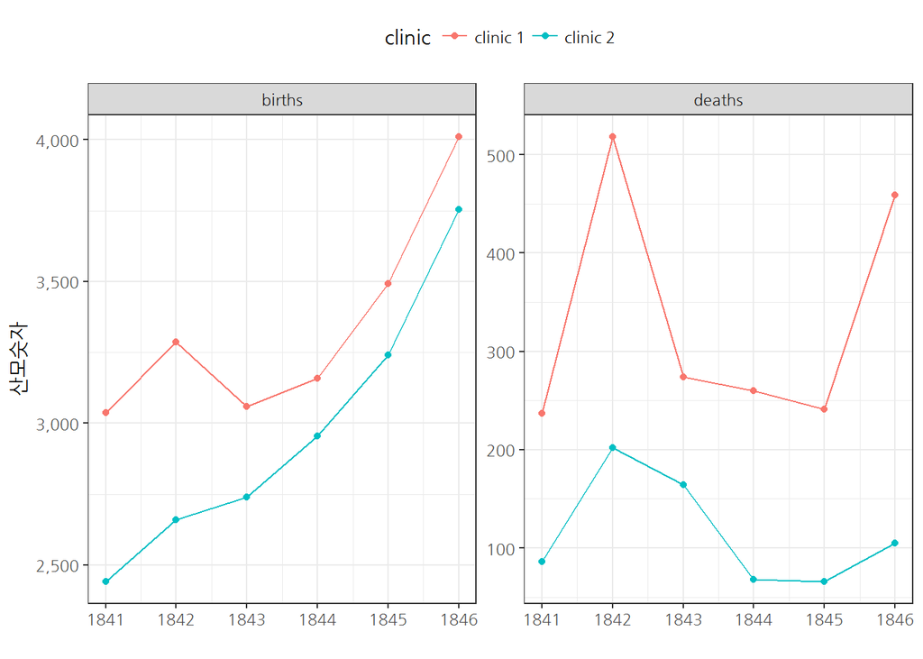

```r
# 2. 탐색적 데이터 분석 -----
## 2.1. 시각화 -----
year_df %>%
  gather(출생사망, 산모숫자, -year, -clinic) %>%
  ggplot(aes(x=year, y=산모숫자, color=clinic)) +
    geom_point() +
    geom_line() +
    facet_wrap( ~ 출생사망, scales="free") +
    theme_bw(base_family = "NanumGothic") +
    labs(x="", y="산모숫자") +
    scale_y_continuous(labels = scales::comma) +
    theme(legend.position = "top")
```

## 3.2. 연도별 사망율표

연도별 시계열 산모사망률을 도식화해보자.

```r
## 2.2. 표 -----
### 연도별 산모사망률
year_df %>%
  mutate(산모_사망률 = deaths / births) %>%
  datatable() %>%
    formatCurrency(c("births", "deaths"), currency="", digits=0) %>%
    formatPercentage(c("산모_사망률"), digits=1)
```

|  | year | births | deaths | clinic | 산모_사망률 |
| --- | --- | --- | --- | --- | --- |
| 1 | 1841 | 3036 | 237 | clinic 1 | 0.0780632411067194 |
| 2 | 1842 | 3287 | 518 | clinic 1 | 0.157590508062063 |
| 3 | 1843 | 3060 | 274 | clinic 1 | 0.0895424836601307 |
| 4 | 1844 | 3157 | 260 | clinic 1 | 0.0823566677225214 |
| 5 | 1845 | 3492 | 241 | clinic 1 | 0.0690148911798396 |
| 6 | 1846 | 4010 | 459 | clinic 1 | 0.114463840399002 |
| 7 | 1841 | 2442 | 86 | clinic 2 | 0.0352170352170352 |
| 8 | 1842 | 2659 | 202 | clinic 2 | 0.0759684091763821 |
| 9 | 1843 | 2739 | 164 | clinic 2 | 0.0598758671047828 |
| 10 | 1844 | 2956 | 68 | clinic 2 | 0.0230040595399188 |

[output cut: 2 more lines]

## 3.3. 병동별 사망율표

병동별 산모사망률을 표로 비교해보자.

```r
### 병동별 산모사망률
year_df %>%
  group_by(clinic) %>%
  summarize(산모사망 = sum(deaths),
            산모출산 = sum(births)) %>%
  mutate(산모_사망률 = 산모사망/산모출산) %>%
  datatable() %>%
    formatCurrency(c("산모사망", "산모출산"), currency="", digits=0) %>%
    formatPercentage(c("산모_사망률"), digits=1)
```

|  | clinic | 산모사망 | 산모출산 | 산모_사망률 |
| --- | --- | --- | --- | --- |
| 1 | clinic 1 | 1989 | 20042 | 0.0992415926554236 |
| 2 | clinic 2 | 691 | 17791 | 0.0388398628520038 |

# 4. 손씻기 실험

## 4.1. 손씻기 실험 전후 사망률 비교

“1847-06-01”을 기점으로 젬멜바이스 박사는 손씻기 실험을 추진하였고 추진 결과를 데이터로 남겼다.

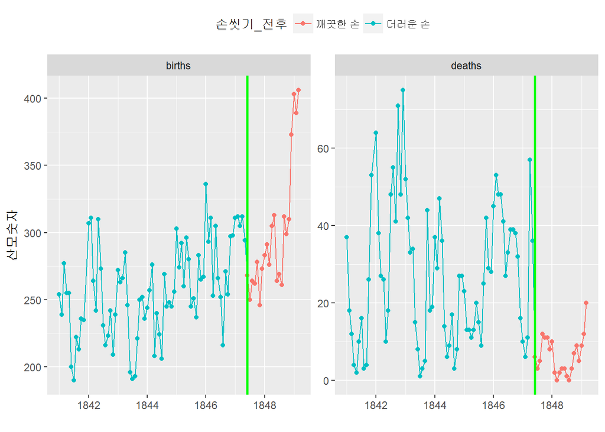

```r
# 3. 손씻기 실험 결과 -----
month_df %>%
  mutate(손씻기_전후 = ifelse(date >= lubridate::ymd('1847-06-01'), "깨끗한 손", "더러운 손")) %>%
  gather(출생사망, 산모숫자, -date, -손씻기_전후) %>%
  ggplot(aes(x=date, y=산모숫자, group=출생사망, color=손씻기_전후)) +
  geom_point() +
  geom_line() +
  geom_vline(xintercept = lubridate::ymd('1847-06-01'), color="green", size=1) +
  facet_wrap( ~ 출생사망, scales="free") +
  labs(x="", y="산모숫자") +
  scale_y_continuous(labels = scales::comma) +
  theme(legend.position = "top")
```

## 4.2. 손씻기 실험 전후 사망률표

“1847-06-01”을 기점으로 젬멜바이스 박사는 손씻기 실험을 추진한 결과를 표로 정리해보자. 손씻은 것이 효과가 있는 것으로 보인다. 과연 그런가?

```r
### 손씻기 전후 산모사망률 비교
month_df %>%
  mutate(손씻기_전후 = ifelse(date >= as.Date('1847-06-01'), "깨끗한 손", "더러운 손")) %>%
  group_by(손씻기_전후) %>%
  summarize(산모사망 = sum(deaths),
            산모출산 = sum(births)) %>%
  mutate(산모_사망률 = 산모사망/산모출산) %>%
  datatable() %>%
  formatCurrency(c("산모사망", "산모출산"), currency="", digits=0) %>%
  formatPercentage(c("산모_사망률"), digits=1)
```

|  | 손씻기_전후 | 산모사망 | 산모출산 | 산모_사망률 |
| --- | --- | --- | --- | --- |
| 1 | 깨끗한 손 | 142 | 6595 | 0.0215314632297195 |
| 2 | 더러운 손 | 2060 | 19571 | 0.105257779367431 |

# 5. 손씻기 효과 검정

“1847-06-01”을 기점으로 젬멜바이스 박사는 손씻기 실험을 추진한 결과를 두개의 집단으로 나눠 두집단간의 사망률의 차이가 있는지를 통계검정으로 확인해보자. 두집단간의 평균 사망률 차이 검정을 위해 $t$-검정을 수행한다.

## 5.1. 손씻기 전후 시각화

본격적인 $t$-검정을 수행하기에 앞서서 시각화를 해서 “깨끗한 손”과 “더러운 손” 두 집단간의 사망률 차이를 시각화해 본다.

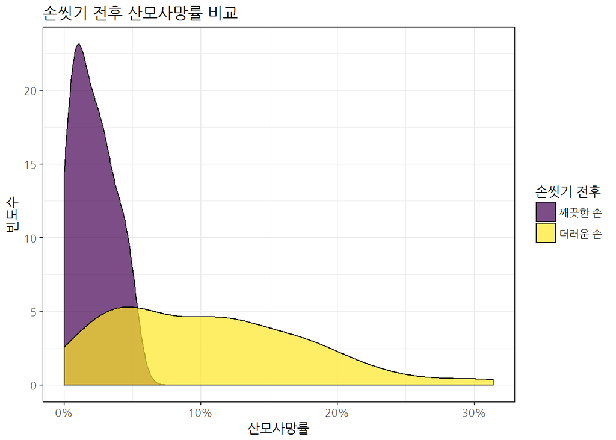

```r
# 4. 통계적 유의성 검정 -----
## 4.1. 데이터 -----
month_df <- month_df %>%
  mutate(손씻기_전후 = ifelse(date >= as.Date('1847-06-01'), "깨끗한 손", "더러운 손")) %>%
  mutate(산모_사망률 = deaths / births)

## 4.2. 시각화 -----
ggplot(data = month_df, mapping = aes(x = 산모_사망률, fill=손씻기_전후)) +
  geom_density(alpha = 0.7) +
  scale_x_continuous(labels = scales::percent) +
  scale_fill_viridis(discrete = TRUE) +
  theme_bw(base_family="NanumGothic") +
  labs(title="손씻기 전후 산모사망률 비교",
       x="산모사망률", y="빈도수", fill="손씻기 전후")
```

## 5.2. 손씻기 효과 검정

전동적인 $t$-검정을 수행해서 “깨끗한 손”과 “더러운 손” 두 집단간의 사망률 차이를 통계적으로 검정해 본다.

```r
## 4.3. 전통적인 통계검정 -----
t.test( 산모_사망률 ~ 손씻기_전후, data = month_df)
```

```
    Welch Two Sample t-test

data:  산모_사망률 by 손씻기_전후
t = -9.6101, df = 92.435, p-value = 1.445e-15
alternative hypothesis: true difference in means is not equal to 0
95 percent confidence interval:
 -0.10130659 -0.06660662
sample estimates:
mean in group 깨끗한 손 mean in group 더러운 손
             0.02109338              0.10504998
```

## 5.3. 손씻기 효과 코딩 기반 검정

전동적인 $t$-검정 대신 코딩 기반 검정을 통해서 “깨끗한 손”과 “더러운 손” 두 집단간의 사망률 차이가 있는지도 살펴보자. 두집단간의 평균차이를 구하고 이것이 두집단이 독립이라는 가정하에 두집단에서 표본을 뽑아 차이를 계산해서 쉽게 센다. p-갑도 계산하고 95% 신뢰구간은 백분위수(Percentile) 방법을 사용해서 계산한다.

```r
## 4.4. 코딩 기반 검정 -----
### 4.4.1. 데이터에서 두 집단 간 차이 산출
hand_diff <- month_df %>%
  group_by(손씻기_전후) %>%
  summarise(mean = mean(산모_사망률)) %>%
  summarise(abs(diff(mean))) %>%
  pull

### 4.4.2. 귀무가설 모형에서 모의실험을 통해서 통계량 산출
null_model <- month_df %>%
  specify(산모_사망률 ~ 손씻기_전후) %>%
  hypothesize(null = "independence") %>%
  generate(reps = 1000, type = "permute") %>%
  calculate(stat = "diff in means", order = c("깨끗한 손", "더러운 손"))

### 4.4.3. p-갑과 95% 신뢰구간: 백분위수(Percentile) 방법
null_model %>%
  summarize(p_value = mean(stat > hand_diff))
```

```
# A tibble: 1 x 1
  p_value
    <dbl>
1       0
```

```r
null_model %>%
  summarize(l = quantile(stat, 0.025),
            u = quantile(stat, 0.975))
```

```
# A tibble: 1 x 2
        l      u
    <dbl>  <dbl>
1 -0.0315 0.0363
```

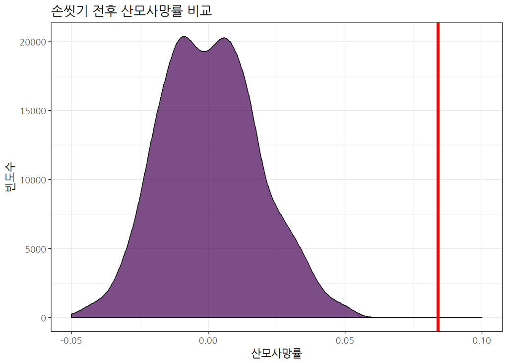

```r
### 4.4.4. 시각화
ggplot(null_model, aes(x = stat, fill="gray75")) +
  geom_density(aes(y=..count..), alpha=0.7) +
  geom_vline(xintercept = hand_diff, color = "red", size=1.5) +
  scale_x_continuous(limits=c(-0.05,0.1)) +
  scale_fill_viridis(discrete = TRUE) +
  theme_bw(base_family="NanumGothic") +
  theme(legend.position = "none") +
  labs(title="손씻기 전후 산모사망률 비교",
       x="산모사망률", y="빈도수", fill="손씻기 전후")
```

[^1]: [박지욱의 진료실의 고고학자(2013.09.13), 손씻기의 화신 산부인과 의사 - 01](http://www.docdocdoc.co.kr/news/articleView.html?idxno=139484)
[^2]: [박지욱의 진료실의 고고학자(2013.09.13), 손씻기의 화신 산부인과 의사 - 02](http://www.docdocdoc.co.kr/news/articleView.html?idxno=139476)